# Project: Investigate a Medical Appointment Dataset

### This dataset collects informationfrom 100k medical appointments inBrazil and is focused on the questionof whether or not patients show upfor their appointment.

#### In this notebook we will investigate the data and answer the question: What factors are important for us to know in order to predict if a patient will show up for their scheduled appointment? Why do patients miss their scheduled appointments?

- Introduction
- Data Wrangling
- Exploratory Data Analysis
- Conclusions

## Introduction

```python
#import libraries
import pandas as pd
import matplotlib.pyplot as plt
import seaborn as sns
sns.set()
```

## Data Wrangling

### General Properties

```python
#load the data
raw_data = pd.read_csv('medical_appointments.csv')
raw_data.head()
```

|  | PatientId | AppointmentID | Gender | ScheduledDay | AppointmentDay | Age | Neighbourhood | Scholarship | Hipertension | Diabetes | Alcoholism | Handcap | SMS_received | No-show |
| --- | --- | --- | --- | --- | --- | --- | --- | --- | --- | --- | --- | --- | --- | --- |
| 0 | 2.987250e+13 | 5642903 | F | 2016-04-29T18:38:08Z | 2016-04-29T00:00:00Z | 62 | JARDIM DA PENHA | 0 | 1 | 0 | 0 | 0 | 0 | No |
| 1 | 5.589978e+14 | 5642503 | M | 2016-04-29T16:08:27Z | 2016-04-29T00:00:00Z | 56 | JARDIM DA PENHA | 0 | 0 | 0 | 0 | 0 | 0 | No |
| 2 | 4.262962e+12 | 5642549 | F | 2016-04-29T16:19:04Z | 2016-04-29T00:00:00Z | 62 | MATA DA PRAIA | 0 | 0 | 0 | 0 | 0 | 0 | No |
| 3 | 8.679512e+11 | 5642828 | F | 2016-04-29T17:29:31Z | 2016-04-29T00:00:00Z | 8 | PONTAL DE CAMBURI | 0 | 0 | 0 | 0 | 0 | 0 | No |
| 4 | 8.841186e+12 | 5642494 | F | 2016-04-29T16:07:23Z | 2016-04-29T00:00:00Z | 56 | JARDIM DA PENHA | 0 | 1 | 1 | 0 | 0 | 0 | No |

```python
# exploring the shape of data
raw_data.shape
```

```
(110527, 14)
```

### Data Cleaning

```python
#making a copy (checkpoint) of the data to save the initial rata version
data = raw_data.copy()
```

#### The columns **PatientId** and **AppointmentID** can be dropped. They don't include any information about the patient

```python
# droping the PatientId and AppointmentID
data.drop(['PatientId', 'AppointmentID'], axis= 1, inplace= True)
```

#### Dealing with duplicates

```python
data.duplicated().sum()
```

```
635
```

```python
data.drop_duplicates(inplace = True)
data.shape
```

```
(109892, 12)
```

```python
data.describe()
```

|  | Age | Scholarship | Hipertension | Diabetes | Alcoholism | Handcap | SMS_received |
| --- | --- | --- | --- | --- | --- | --- | --- |
| count | 109892.000000 | 109892.000000 | 109892.000000 | 109892.000000 | 109892.000000 | 109892.000000 | 109892.000000 |
| mean | 37.089506 | 0.098287 | 0.197248 | 0.071825 | 0.030430 | 0.022131 | 0.322881 |
| std | 23.121196 | 0.297704 | 0.397923 | 0.258199 | 0.171768 | 0.160878 | 0.467580 |
| min | -1.000000 | 0.000000 | 0.000000 | 0.000000 | 0.000000 | 0.000000 | 0.000000 |
| 25% | 18.000000 | 0.000000 | 0.000000 | 0.000000 | 0.000000 | 0.000000 | 0.000000 |
| 50% | 37.000000 | 0.000000 | 0.000000 | 0.000000 | 0.000000 | 0.000000 | 0.000000 |
| 75% | 55.000000 | 0.000000 | 0.000000 | 0.000000 | 0.000000 | 0.000000 | 1.000000 |
| max | 115.000000 | 1.000000 | 1.000000 | 1.000000 | 1.000000 | 4.000000 | 1.000000 |

```python
data.info()
```

```
<class 'pandas.core.frame.DataFrame'>
Int64Index: 109892 entries, 0 to 110526
Data columns (total 12 columns):
 #   Column          Non-Null Count   Dtype
---  ------          --------------   -----
 0   Gender          109892 non-null  object
 1   ScheduledDay    109892 non-null  object
 2   AppointmentDay  109892 non-null  object
 3   Age             109892 non-null  int64
 4   Neighbourhood   109892 non-null  object
 5   Scholarship     109892 non-null  int64
 6   Hipertension    109892 non-null  int64
 7   Diabetes        109892 non-null  int64
 8   Alcoholism      109892 non-null  int64
 9   Handcap         109892 non-null  int64
 10  SMS_received    109892 non-null  int64
 11  No-show         109892 non-null  object
dtypes: int64(7), object(5)
memory usage: 10.9+ MB
```

### Plotting a histogram of numerical data

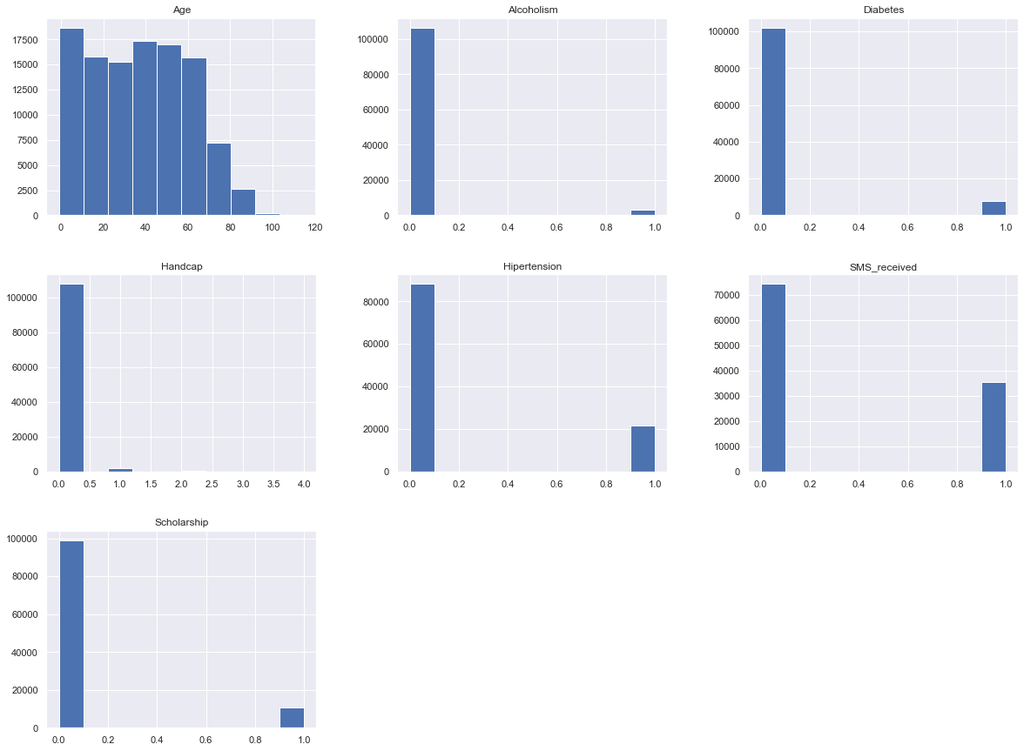

```python
data.hist(figsize=(20,15));
```

### Let's also investigate the **Neighbourhood** column

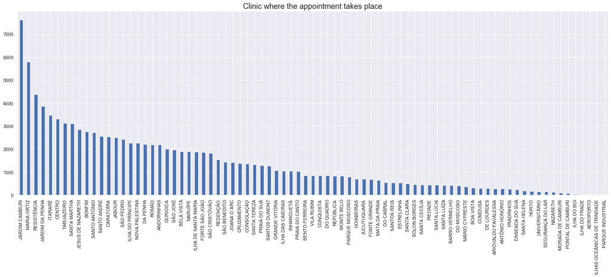

```python
data['Neighbourhood'].value_counts().plot(kind='bar', figsize=(25,8))
plt.title('Clinic where the appointment takes place', fontsize= 18);
```

### From this point of view the data looks good. The most columns represent a categorical data.

### Let's take a closer look at the Age column and age distribution between 55 and 115 to decide if there are some outliers

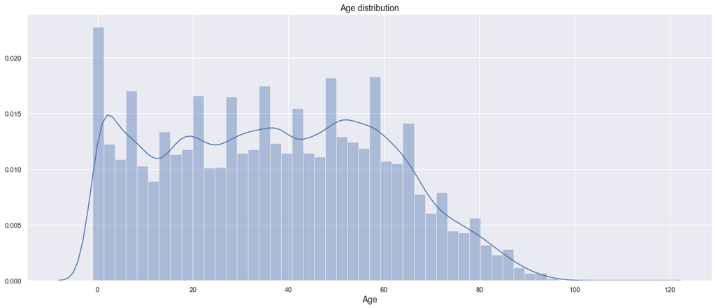

```python
plt.figure(figsize=(20,8))
sns.distplot(data['Age'])
plt.title('Age distribution', fontsize=14)
plt.xlabel('Age', fontsize=14)
plt.show()
```

#### Interim conclusions about the given data:

1. no missing data
2. Min vlaue of **Age** column is -1. Max value is 115 but let's assume for Brazil it could be possible.
3. **ScheduledDay** and **AppointmentDay** are treated as an object data, not as a date object

#### Replacing the age of -1 with value of 0

```python
data['Age'][data['Age'] == -1] = 0
```

```python
data.describe()
```

|  | Age | Scholarship | Hipertension | Diabetes | Alcoholism | Handcap | SMS_received |
| --- | --- | --- | --- | --- | --- | --- | --- |
| count | 109892.000000 | 109892.000000 | 109892.000000 | 109892.000000 | 109892.000000 | 109892.000000 | 109892.000000 |
| mean | 37.089515 | 0.098287 | 0.197248 | 0.071825 | 0.030430 | 0.022131 | 0.322881 |
| std | 23.121181 | 0.297704 | 0.397923 | 0.258199 | 0.171768 | 0.160878 | 0.467580 |
| min | 0.000000 | 0.000000 | 0.000000 | 0.000000 | 0.000000 | 0.000000 | 0.000000 |
| 25% | 18.000000 | 0.000000 | 0.000000 | 0.000000 | 0.000000 | 0.000000 | 0.000000 |
| 50% | 37.000000 | 0.000000 | 0.000000 | 0.000000 | 0.000000 | 0.000000 | 0.000000 |
| 75% | 55.000000 | 0.000000 | 0.000000 | 0.000000 | 0.000000 | 0.000000 | 1.000000 |
| max | 115.000000 | 1.000000 | 1.000000 | 1.000000 | 1.000000 | 4.000000 | 1.000000 |

```python
data.head()
```

|  | Gender | ScheduledDay | AppointmentDay | Age | Neighbourhood | Scholarship | Hipertension | Diabetes | Alcoholism | Handcap | SMS_received | No-show |
| --- | --- | --- | --- | --- | --- | --- | --- | --- | --- | --- | --- | --- |
| 0 | F | 2016-04-29T18:38:08Z | 2016-04-29T00:00:00Z | 62 | JARDIM DA PENHA | 0 | 1 | 0 | 0 | 0 | 0 | No |
| 1 | M | 2016-04-29T16:08:27Z | 2016-04-29T00:00:00Z | 56 | JARDIM DA PENHA | 0 | 0 | 0 | 0 | 0 | 0 | No |
| 2 | F | 2016-04-29T16:19:04Z | 2016-04-29T00:00:00Z | 62 | MATA DA PRAIA | 0 | 0 | 0 | 0 | 0 | 0 | No |
| 3 | F | 2016-04-29T17:29:31Z | 2016-04-29T00:00:00Z | 8 | PONTAL DE CAMBURI | 0 | 0 | 0 | 0 | 0 | 0 | No |
| 4 | F | 2016-04-29T16:07:23Z | 2016-04-29T00:00:00Z | 56 | JARDIM DA PENHA | 0 | 1 | 1 | 0 | 0 | 0 | No |

#### Dealing with date type objects

```python
data['ScheduledDay'] = pd.to_datetime(data['ScheduledDay'])
data['AppointmentDay'] = pd.to_datetime(data['AppointmentDay'])
```

```python
data.head()
```

|  | Gender | ScheduledDay | AppointmentDay | Age | Neighbourhood | Scholarship | Hipertension | Diabetes | Alcoholism | Handcap | SMS_received | No-show |
| --- | --- | --- | --- | --- | --- | --- | --- | --- | --- | --- | --- | --- |
| 0 | F | 2016-04-29 18:38:08+00:00 | 2016-04-29 00:00:00+00:00 | 62 | JARDIM DA PENHA | 0 | 1 | 0 | 0 | 0 | 0 | No |
| 1 | M | 2016-04-29 16:08:27+00:00 | 2016-04-29 00:00:00+00:00 | 56 | JARDIM DA PENHA | 0 | 0 | 0 | 0 | 0 | 0 | No |
| 2 | F | 2016-04-29 16:19:04+00:00 | 2016-04-29 00:00:00+00:00 | 62 | MATA DA PRAIA | 0 | 0 | 0 | 0 | 0 | 0 | No |
| 3 | F | 2016-04-29 17:29:31+00:00 | 2016-04-29 00:00:00+00:00 | 8 | PONTAL DE CAMBURI | 0 | 0 | 0 | 0 | 0 | 0 | No |
| 4 | F | 2016-04-29 16:07:23+00:00 | 2016-04-29 00:00:00+00:00 | 56 | JARDIM DA PENHA | 0 | 1 | 1 | 0 | 0 | 0 | No |

```python
data.info()
```

```
<class 'pandas.core.frame.DataFrame'>
Int64Index: 109892 entries, 0 to 110526
Data columns (total 12 columns):
 #   Column          Non-Null Count   Dtype
---  ------          --------------   -----
 0   Gender          109892 non-null  object
 1   ScheduledDay    109892 non-null  datetime64[ns, UTC]
 2   AppointmentDay  109892 non-null  datetime64[ns, UTC]
 3   Age             109892 non-null  int64
 4   Neighbourhood   109892 non-null  object
 5   Scholarship     109892 non-null  int64
 6   Hipertension    109892 non-null  int64
 7   Diabetes        109892 non-null  int64
 8   Alcoholism      109892 non-null  int64
 9   Handcap         109892 non-null  int64
 10  SMS_received    109892 non-null  int64
 11  No-show         109892 non-null  object
dtypes: datetime64[ns, UTC](2), int64(7), object(3)
memory usage: 10.9+ MB
```

#### Renamimg the No-Show column into the Showed Up for better understanding

```python
data.columns
```

```
Index(['Gender', 'ScheduledDay', 'AppointmentDay', 'Age', 'Neighbourhood',
       'Scholarship', 'Hipertension', 'Diabetes', 'Alcoholism', 'Handcap',
       'SMS_received', 'No-show'],
      dtype='object')
```

```python
col_names = ['Gender', 'ScheduledDay', 'AppointmentDay', 'Age', 'Neighbourhood',
             'Scholarship', 'Hipertension', 'Diabetes', 'Alcoholism', 'Handcap',
             'SMS_received', 'Showed Up']
```

```python
#renaming the column name
data.columns = col_names
data.head()
```

|  | Gender | ScheduledDay | AppointmentDay | Age | Neighbourhood | Scholarship | Hipertension | Diabetes | Alcoholism | Handcap | SMS_received | Showed Up |
| --- | --- | --- | --- | --- | --- | --- | --- | --- | --- | --- | --- | --- |
| 0 | F | 2016-04-29 18:38:08+00:00 | 2016-04-29 00:00:00+00:00 | 62 | JARDIM DA PENHA | 0 | 1 | 0 | 0 | 0 | 0 | No |
| 1 | M | 2016-04-29 16:08:27+00:00 | 2016-04-29 00:00:00+00:00 | 56 | JARDIM DA PENHA | 0 | 0 | 0 | 0 | 0 | 0 | No |
| 2 | F | 2016-04-29 16:19:04+00:00 | 2016-04-29 00:00:00+00:00 | 62 | MATA DA PRAIA | 0 | 0 | 0 | 0 | 0 | 0 | No |
| 3 | F | 2016-04-29 17:29:31+00:00 | 2016-04-29 00:00:00+00:00 | 8 | PONTAL DE CAMBURI | 0 | 0 | 0 | 0 | 0 | 0 | No |
| 4 | F | 2016-04-29 16:07:23+00:00 | 2016-04-29 00:00:00+00:00 | 56 | JARDIM DA PENHA | 0 | 1 | 1 | 0 | 0 | 0 | No |

```python
#adaptation of the content of the Showed Up column
data['Showed Up'] = data['Showed Up'].map({'No':'Yes', 'Yes':'No'})
data.head()
```

|  | Gender | ScheduledDay | AppointmentDay | Age | Neighbourhood | Scholarship | Hipertension | Diabetes | Alcoholism | Handcap | SMS_received | Showed Up |
| --- | --- | --- | --- | --- | --- | --- | --- | --- | --- | --- | --- | --- |
| 0 | F | 2016-04-29 18:38:08+00:00 | 2016-04-29 00:00:00+00:00 | 62 | JARDIM DA PENHA | 0 | 1 | 0 | 0 | 0 | 0 | Yes |
| 1 | M | 2016-04-29 16:08:27+00:00 | 2016-04-29 00:00:00+00:00 | 56 | JARDIM DA PENHA | 0 | 0 | 0 | 0 | 0 | 0 | Yes |
| 2 | F | 2016-04-29 16:19:04+00:00 | 2016-04-29 00:00:00+00:00 | 62 | MATA DA PRAIA | 0 | 0 | 0 | 0 | 0 | 0 | Yes |
| 3 | F | 2016-04-29 17:29:31+00:00 | 2016-04-29 00:00:00+00:00 | 8 | PONTAL DE CAMBURI | 0 | 0 | 0 | 0 | 0 | 0 | Yes |
| 4 | F | 2016-04-29 16:07:23+00:00 | 2016-04-29 00:00:00+00:00 | 56 | JARDIM DA PENHA | 0 | 1 | 1 | 0 | 0 | 0 | Yes |

```python
#creating a checkpoint with clean data
df = data.copy()
```

```python
df.head()
```

|  | Gender | ScheduledDay | AppointmentDay | Age | Neighbourhood | Scholarship | Hipertension | Diabetes | Alcoholism | Handcap | SMS_received | Showed Up |
| --- | --- | --- | --- | --- | --- | --- | --- | --- | --- | --- | --- | --- |
| 0 | F | 2016-04-29 18:38:08+00:00 | 2016-04-29 00:00:00+00:00 | 62 | JARDIM DA PENHA | 0 | 1 | 0 | 0 | 0 | 0 | Yes |
| 1 | M | 2016-04-29 16:08:27+00:00 | 2016-04-29 00:00:00+00:00 | 56 | JARDIM DA PENHA | 0 | 0 | 0 | 0 | 0 | 0 | Yes |
| 2 | F | 2016-04-29 16:19:04+00:00 | 2016-04-29 00:00:00+00:00 | 62 | MATA DA PRAIA | 0 | 0 | 0 | 0 | 0 | 0 | Yes |
| 3 | F | 2016-04-29 17:29:31+00:00 | 2016-04-29 00:00:00+00:00 | 8 | PONTAL DE CAMBURI | 0 | 0 | 0 | 0 | 0 | 0 | Yes |
| 4 | F | 2016-04-29 16:07:23+00:00 | 2016-04-29 00:00:00+00:00 | 56 | JARDIM DA PENHA | 0 | 1 | 1 | 0 | 0 | 0 | Yes |